# Solutions

**Exercice 1 :** Rechercher et supprimer de valeurs en double

```python
import numpy as np
import pandas as pd
```

```python
données = pd . DataFrame ({ "a" :[ 1 , 5 ] * 3 , "b" :[ 1 , 1 , 2 , 3 , 2 , 3 ]})
données
```

|  | a | b |
| --- | --- | --- |
| 0 | 1 | 1 |
| 1 | 5 | 1 |
| 2 | 1 | 2 |
| 3 | 5 | 3 |
| 4 | 1 | 2 |
| 5 | 5 | 3 |

Ecrire un programme Pandas qui sert à afficher les duplicates et de les supprimer par la suite

```python
#solution
```

**Exercice 2 :** Mapping

```python
import pandas as pd
data={'Name':['A','B','C','D'],'Age':[42,54,20,63]}
df=pd.DataFrame(data,index=['value1','value2','value3','value4'])
df
```

|  | Name | Age |
| --- | --- | --- |
| value1 | A | 42 |
| value2 | B | 54 |
| value3 | C | 20 |
| value4 | D | 63 |

```python
score={'A':24,'B':30,'C':36,'D':42}
# Conversion du premier caractère du nom en majuscule pour que les noms soient identiques.
n=df["Name"].str.capitalize()
n
```

```
value1    A
value2    B
value3    C
value4    D
Name: Name, dtype: object
```

Ecrire un programme Pandas qui sert à ajouter la variable de score à l'ensemble de données df à l'aide de la méthode map().

```python
#solution
```

**Exercice 3 :** Remplacement

```python
s = pd.Series([ 14 , 55 , 87 , 966 , 78 , 44 ])
s
```

```
0     14
1     55
2     87
3    966
4     78
5     44
dtype: int64
```

Ecrire un programme Pandas qui permet de remplacer la valeur de 87 par nan

```python
#solution
```

Ecrire un programme Pandas qui permet de remplacer les valeurs 78 et 14 par nan et 566 respectivement

```python
#solution
```

**Exercice 4 :** Renaming

```python
import pandas as pd
import numpy as np
df=pd.DataFrame(np.arange(12).reshape(3,4),index=[0,1,2],columns=["a","b","c","d"])
df
```

|  | a | b | c | d |
| --- | --- | --- | --- | --- |
| 0 | 0 | 1 | 2 | 3 |
| 1 | 4 | 5 | 6 | 7 |
| 2 | 8 | 9 | 10 | 11 |

```python
#Create a variable and pass it into the dataset
s=pd.Series(["one","two","three"])
df.index=df.index.map(s)
df
```

|  | a | b | c | d |
| --- | --- | --- | --- | --- |
| one | 0 | 1 | 2 | 3 |
| two | 4 | 5 | 6 | 7 |
| three | 8 | 9 | 10 | 11 |

Mettez en majuscule les noms de ligne et de colonne avec la méthode de renommage

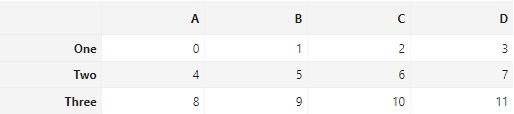

```python
#solution
```

**Exercice 5 :** Trouver des valeurs spécifique dans un ensemble de données

```python
data = pd . DataFrame ( np . random . randn ( 1000 , 4 ))
data
```

|  | 0 | 1 | 2 | 3 |
| --- | --- | --- | --- | --- |
| 0 | 1.616920 | -0.642890 | 0.794632 | -0.735338 |
| 1 | -0.837791 | 1.458693 | 0.172070 | -0.602371 |
| 2 | -1.152141 | -1.788366 | -0.219525 | 0.712704 |
| 3 | 1.181751 | 0.178818 | 0.377092 | -0.377373 |
| 4 | 0.467218 | 1.157019 | -1.429485 | -1.818803 |
| ... | ... | ... | ... | ... |
| 995 | 0.795813 | 0.264559 | 2.136728 | -1.027800 |
| 996 | -1.734192 | 0.685263 | 1.300703 | 0.782458 |
| 997 | 0.293207 | -0.819040 | -0.569724 | -1.651684 |
| 998 | 1.595878 | -0.061226 | 2.434815 | 0.047087 |
| 999 | -0.709029 | -1.053145 | -0.442337 | 0.403489 |

1000 rows × 4 columns

```python
data.head()
```

|  | 0 | 1 | 2 | 3 |
| --- | --- | --- | --- | --- |
| 0 | 1.616920 | -0.642890 | 0.794632 | -0.735338 |
| 1 | -0.837791 | 1.458693 | 0.172070 | -0.602371 |
| 2 | -1.152141 | -1.788366 | -0.219525 | 0.712704 |
| 3 | 1.181751 | 0.178818 | 0.377092 | -0.377373 |
| 4 | 0.467218 | 1.157019 | -1.429485 | -1.818803 |

recherchons les valeurs dont la valeur absolue dépasse 3 dans une colonne avec l'index 1.

```python
#solution
```

**Exercice 6 :** One hot Encoding

```python
import pandas as pd

ids = [11, 22, 33, 44, 55, 66, 77]
countries = ['Spain', 'France', 'Spain', 'Germany', 'France']

df = pd.DataFrame(list(zip(ids, countries)),
                  columns=['Ids', 'Countries'])
```

```python
df.head()
```

|  | Ids | Countries |
| --- | --- | --- |
| 0 | 11 | Spain |
| 1 | 22 | France |
| 2 | 33 | Spain |
| 3 | 44 | Germany |
| 4 | 55 | France |

Convertissez les valeurs de la colonne Countries en vecteurs one hot encoding :

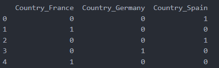

```python
#solution
```